# Dataset Overview

This is a dataset for death counts in a state in US. This dataset counts the death cases for each disease from 2014 to 2019.

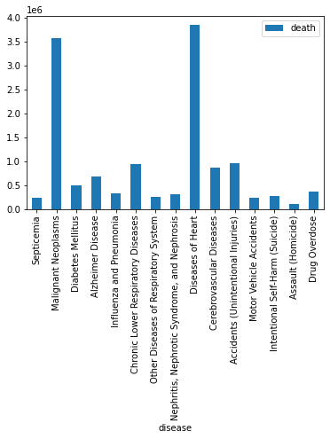

```python
#bar chart to showcase the number of death cases for each disease

disease_and_deaths_df = pd.DataFrame({'disease':columns, 'death':sums})

disease_and_deaths_df.plot.bar(x = 'disease', y = 'death')
```

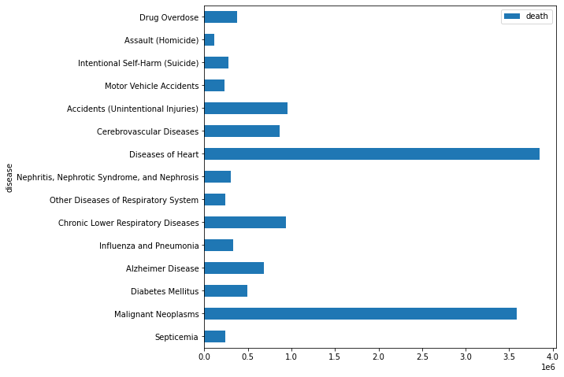

```python
disease_and_deaths_df.plot.barh(x = 'disease', y = 'death', figsize=(8, 8))
```

- The highest number of death was due to **Heart Diseases** and **Malignant Neoplasms** which is **Cancer**.
- Another thing that surprised me is that the total death cases due to diabetes is 492238 which is too low if compared to Heart diseases and cencer although there are a lot of patients that suffer from diabetes (about 422 millions) than those who suffer from Heart diseases or Cancer (According to WHO)
- The number of Peaple who died due to drug overdose is greater than those who died due to Motor Vehicle Accident, Suicide, Homocide and some respiatory system diseases so it is really important for health care providers to give due care to this point.

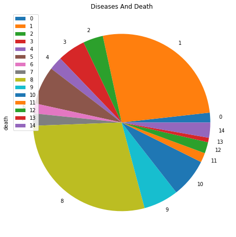

```python
# pie cart to do the samething
disease_and_deaths_df.plot.pie(x = 'disease', y = 'death', figsize=(8, 8), title="Diseases And Death")
```

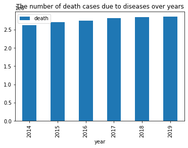

```python
years_and_deaths_df = pd.DataFrame({'year':years, 'death':years_all_sums})
years_and_deaths_df.plot.bar(x='year', y='death', title='The number of death cases due to diseases over years')
```

**We can say that the death rate is slightly growing.**

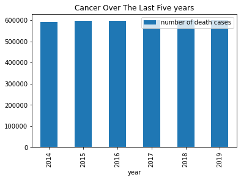

```python
cancer_over_years = np.array(cancer_over_years)
cancer_over_years_df = pd.DataFrame({'year':years, 'number of death cases':cancer_over_years})

cancer_over_years_df.plot.bar(x = "year", y='number of death cases', title='Cancer Over The Last Five years')
```

**Also there is a slight growth in death rate due to cancerious tumours**

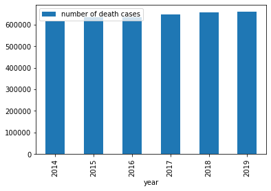

```python
heart_over_years_df = pd.DataFrame({'year':years, 'number of death cases':heart_over_years})
heart_over_years_df.plot.bar(x='year', y='number of death cases')
```

**Same thing here, but the growth in death rate is slightly greater than cancer**

# Conslusions

- The highest number of death was due to **Heart Diseases** and **Malignant Neoplasms** which is **Cancer**.
- Another thing that surprised me is that the total death cases due to diabetes is 492238 which is too low if compared to Heart diseases and cencer although there are a lot of patients that suffer from diabetes (about 422 millions) than those who suffer from Heart diseases or Cancer (According to WHO)
- The number of Peaple who died due to drug overdose is greater than those who died due to Motor Vehicle Accident, Suicide, Homocide and some respiatory system diseases so it is really important for health care providers to give due care to this point.
- There is a slight growth in the number of death cases in general and duo to Heart diseases and Cancer in particular.
- It is normal that the greatest number of peaple died due to natural causes but we are interested in diseases
- 275012 people died due to Suicide so, we should extert more effort in psycology to reduce this number
- Also There are 232224 people died because of road accidents so adopting AI and self-drivng cars , I think, will help reduce this number and save many people from death.